# X-Vertices Analysis

Sarah Herald

This is an [R Markdown](https://rmarkdown.rstudio.com) Notebook.

## Summary

Two separate models were analyzed: reaction time and accuracy. The data were analyzed using generalized linear mixed effects models.

## Initial Setup

A few notes about the variables used:

1. For the reaction time analysis, only correct and partially correct trials are being used.
2. Accuracy is defined as the odds of correctly or partially correctly naming the object compared to incorrectly naming the object or failing to respond within the time limit provided.
3. Trials with extraneous background noise were not used in any of the analyses.
4. The number of times a stimulus has been shown (including the current trial) is called “repetition.” Because repetition effects will eventually saturate, repetition is modeled as (1 - x^-1.5), where x is the number of times the stimulus has been seen. Thus, the repetition values of (1, 2, 3, 4, 5) are transformed into (0, .65, .81, .88, .91). Anything between x^-1.25 and x^-2 seems to work about equally well for the model fit.
5. The “Condition” factor variable is set up so that “o,” the intact images with nothing added, is the baseline. Thus, all GLMM estimates for the other conditions (i.e. “cd”, “cdx”, “cdl”, “ox”) should be interpreted as the effect of that condition relative to the intact images (“o”).

## Data Summary

### Reaction Time

| ScoredResponse | Condition | Average_RT | Std.Dev. | n |
| --- | --- | --- | --- | --- |
| correct | o | 983.8265 | 552.1094 | 2384 |
| correct | ox | 1019.8393 | 588.7502 | 2370 |
| correct | cd | 1020.4486 | 583.1575 | 2372 |
| correct | cdx | 1051.3596 | 561.8784 | 2389 |
| correct | cdl | 1143.0247 | 679.7088 | 2283 |
| partial | o | 1264.4005 | 765.1913 | 85 |
| partial | ox | 1312.2655 | 863.0208 | 99 |
| partial | cd | 1214.8254 | 811.9639 | 110 |
| partial | cdx | 1459.3379 | 956.2399 | 99 |
| partial | cdl | 1707.7821 | 1227.8316 | 97 |

[output cut: 10 more lines]

### Accuracy

| Condition | Percent_Correct | Std.Dev. | n |
| --- | --- | --- | --- |
| o | 95.14451 | 21.49771 | 2595 |
| ox | 95.32819 | 21.10753 | 2590 |
| cd | 95.46154 | 20.81863 | 2600 |
| cdx | 94.13545 | 23.50044 | 2643 |
| cdl | 91.57368 | 27.78356 | 2599 |

## Results

### Reaction Time

Reaction time is modeled as an Inverse Gaussian distribution with the identity link function as suggested by Lo & Andrews (2015).

Condition and repetition are modeled as fixed effects while SubjectID and Stimulus are modeled as random intercepts.

Whether an answer was graded as fully or partially correct has not been added as a regressor. The number of partially correct trials is much smaller than the correct trials (about 1 partial : 20 correct) and causes issues with model convergence. It’s also not clear how meaningful the distinction between the two scores is.

```r
model_rt <- glmer(RT ~ Repetition + Condition
                  + (1 | SubjectID) + (1 | Stimulus),
                  data = data_rt,
                  family = inverse.gaussian(link = "identity"),
                  glmerControl(optimizer = "bobyqa"))
```

A table of the results can be seen below.

|  | RT |  |  |
| --- | --- | --- | --- |
| Predictors | Estimates | CI | p |
| (Intercept) | 1359.22 | 1340.95 – 1377.48 | **<0.001** |
| Repetition | -290.89 | -307.79 – -273.99 | **<0.001** |
| ox | 27.82 | 12.85 – 42.78 | **<0.001** |
| cd | 30.55 | 13.38 – 47.73 | **<0.001** |
| cdx | 58.82 | 40.42 – 77.23 | **<0.001** |
| cdl | 130.11 | 113.13 – 147.08 | **<0.001** |
| Random Effects |  |  |  |
| σ<sup>2</sup> | 0.00 |  |  |
| τ<sub>00</sub> <sub>Stimulus</sub> | 2033.00 |  |  |
| τ<sub>00</sub> <sub>SubjectID</sub> | 3395.35 |  |  |
| ICC <sub>Stimulus</sub> | 0.37 |  |  |
| ICC <sub>SubjectID</sub> | 0.63 |  |  |
| Observations | 12288 |  |  |
| Marginal R<sup>2</sup> / Conditional R<sup>2</sup> | 0.671 / 1.000 |  |  |

### Accuracy

Accuracy is modeled as a Binomial distribution with the logit link function.

Condition and repetition are modeled as fixed effects while SubjectID and Stimulus are modeled as random intercepts.

```r
model_acc <- glmer(ScoredResponse ~ Repetition + Condition
                   + (1 | SubjectID) + (1 | Stimulus),
                   data = data_acc,
                   family = binomial(link = "logit"),
                   glmerControl(optimizer = "bobyqa"))
```

A table of the results can be seen below.

|  | Scored Response |  |  |
| --- | --- | --- | --- |
| Predictors | Odds Ratios | CI | p |
| (Intercept) | 0.03 | 0.02 – 0.06 | **<0.001** |
| Repetition | 0.36 | 0.29 – 0.45 | **<0.001** |
| ox | 0.96 | 0.73 – 1.26 | 0.759 |
| cd | 0.91 | 0.69 – 1.20 | 0.510 |
| cdx | 1.27 | 0.98 – 1.64 | 0.068 |
| cdl | 1.99 | 1.56 – 2.53 | **<0.001** |
| Random Effects |  |  |  |
| σ<sup>2</sup> | 3.29 |  |  |
| τ<sub>00</sub> <sub>Stimulus</sub> | 1.62 |  |  |
| τ<sub>00</sub> <sub>SubjectID</sub> | 1.11 |  |  |
| ICC <sub>Stimulus</sub> | 0.27 |  |  |
| ICC <sub>SubjectID</sub> | 0.19 |  |  |
| Observations | 13027 |  |  |
| Marginal R<sup>2</sup> / Conditional R<sup>2</sup> | 0.032 / 0.471 |  |  |

### Multiple Comparisons - RT

A pairwise comparison between all of the conditions (excluding the intact image) can be seen below. The Holm-Bonferroni method is used to correct for multiple comparisons.

```
##
##   Simultaneous Tests for General Linear Hypotheses
##
## Multiple Comparisons of Means: Tukey Contrasts
##
##
## Fit: glmer(formula = RT ~ Repetition + Condition + (1 | SubjectID) +
##     (1 | Stimulus), data = data_rt, family = inverse.gaussian(link = "identity"),
##     control = glmerControl(optimizer = "bobyqa"))
##
## Linear Hypotheses:
##                Estimate Std. Error z value Pr(>|z|)
## ox - o == 0      27.819      7.635   3.643  0.00135 **
## cd - o == 0      30.552      8.764   3.486  0.00196 **
## cdx - o == 0     58.824      9.392   6.263 2.64e-09 ***
## cdl - o == 0    130.108      8.661  15.023  < 2e-16 ***
## cd - ox == 0      2.734     11.595   0.236  0.81362
## cdx - ox == 0    31.006     11.503   2.696  0.02108 *
## cdl - ox == 0   102.289     11.434   8.946  < 2e-16 ***
## cdx - cd == 0    28.272     12.911   2.190  0.05707 .
## cdl - cd == 0    99.556     11.815   8.427  < 2e-16 ***
## cdl - cdx == 0   71.284     12.046   5.918 1.96e-08 ***
## ---
## Signif. codes:  0 '***' 0.001 '**' 0.01 '*' 0.05 '.' 0.1 ' ' 1
## (Adjusted p values reported -- holm method)
```

### Multiple Comparisons - Accuracy

A pairwise comparison between all of the conditions (excluding the intact image) can be seen below. The Holm-Bonferroni method is used to correct for multiple comparisons.

```
##
##   Simultaneous Tests for General Linear Hypotheses
##
## Multiple Comparisons of Means: Tukey Contrasts
##
##
## Fit: glmer(formula = ScoredResponse ~ Repetition + Condition + (1 |
##     SubjectID) + (1 | Stimulus), data = data_acc, family = binomial(link = "logit"),
##     control = glmerControl(optimizer = "bobyqa"))
##
## Linear Hypotheses:
##                Estimate Std. Error z value Pr(>|z|)
## ox - o == 0     -0.0425     0.1387  -0.306   1.0000
## cd - o == 0     -0.0919     0.1394  -0.659   1.0000
## cdx - o == 0     0.2396     0.1314   1.823   0.2732
## cdl - o == 0     0.6865     0.1243   5.521 2.70e-07 ***
## cd - ox == 0    -0.0494     0.1406  -0.351   1.0000
## cdx - ox == 0    0.2821     0.1328   2.124   0.1683
## cdl - ox == 0    0.7290     0.1258   5.794 6.18e-08 ***
## cdx - cd == 0    0.3315     0.1335   2.483   0.0782 .
## cdl - cd == 0    0.7784     0.1266   6.149 7.79e-09 ***
## cdl - cdx == 0   0.4469     0.1175   3.803   0.0010 **
## ---
## Signif. codes:  0 '***' 0.001 '**' 0.01 '*' 0.05 '.' 0.1 ' ' 1
## (Adjusted p values reported -- holm method)
```

## Figures

### Summary

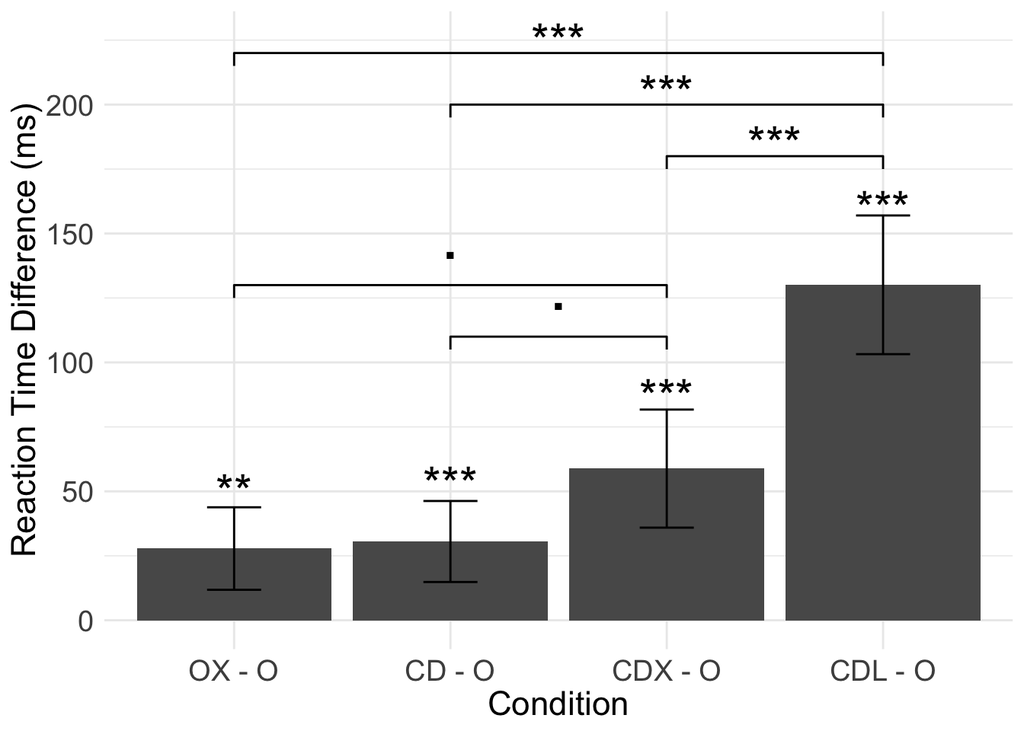

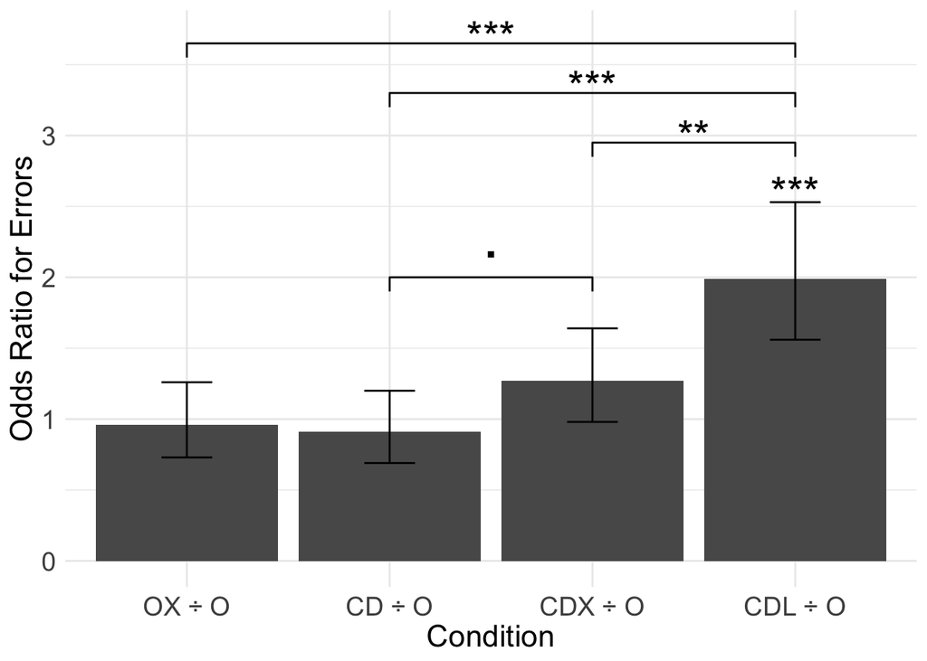

### Reaction Time

The black line on each figure indicates no effect. The errorbars indicate the 95% confidence interval.

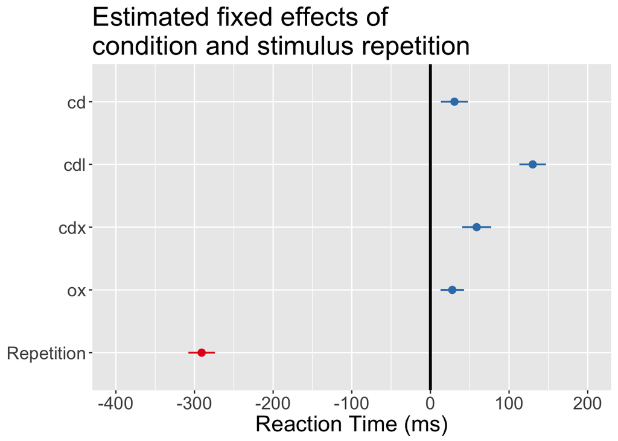

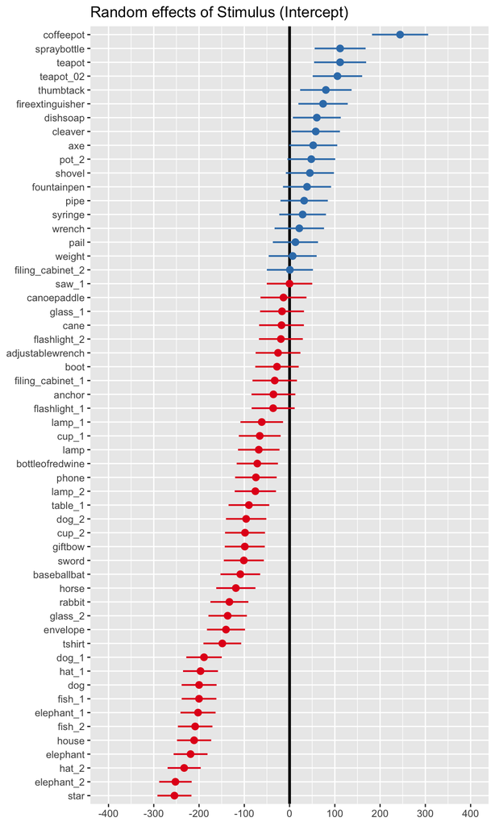

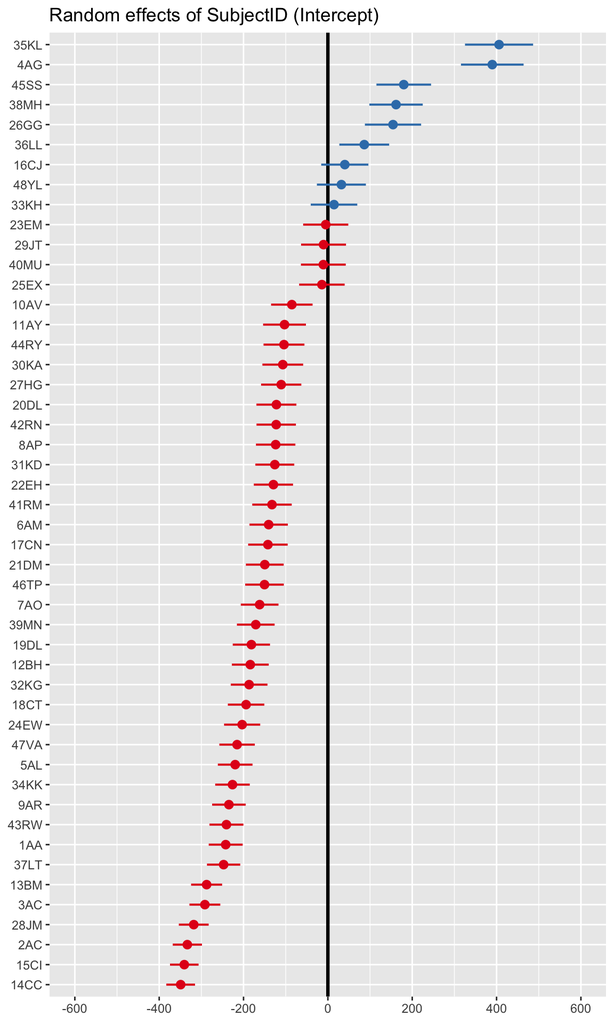

### Accuracy

The black line on each figure indicates no effect. The errorbars indicate the 95% confidence interval.

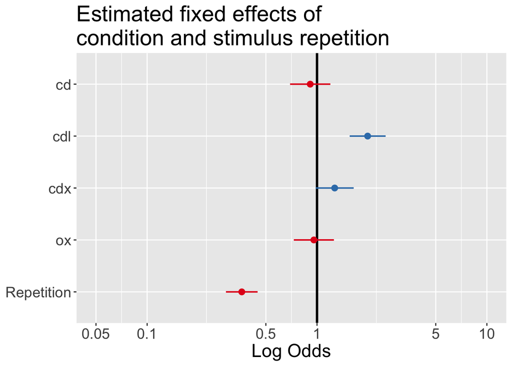

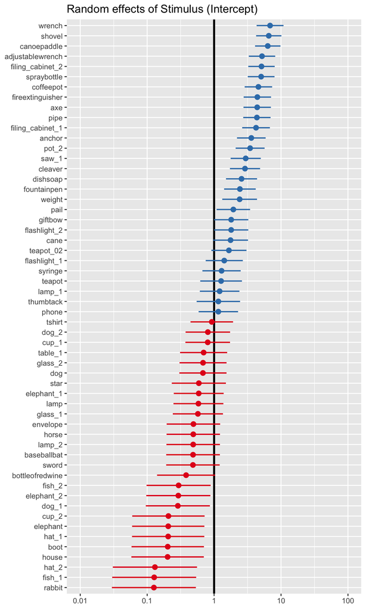

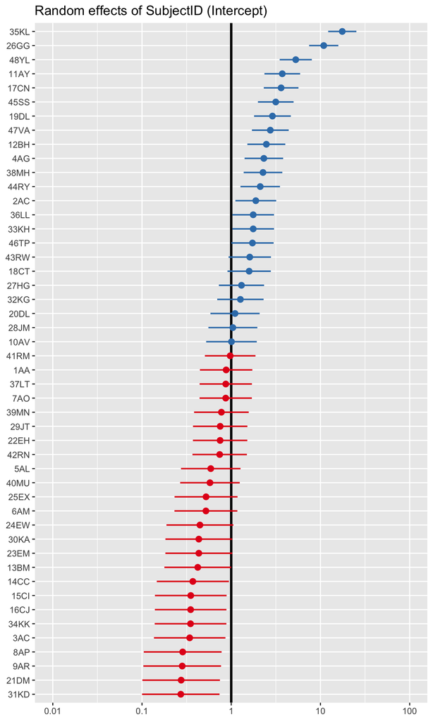

## Alternative Models

A look at alternative models to see why using the Inverse Gaussian distribution is the best solution.

### Model Summaries

#### Raw RT

|  | RT |  |  |
| --- | --- | --- | --- |
| Predictors | Estimates | CI | p |
| (Intercept) | 1251.60 | 1159.55 – 1343.65 | **<0.001** |
| Repetition | -365.62 | -393.88 – -337.35 | **<0.001** |
| ox | 42.64 | 13.32 – 71.96 | **0.004** |
| cd | 35.22 | 5.95 – 64.50 | **0.018** |
| cdx | 72.96 | 43.69 – 102.22 | **<0.001** |
| cdl | 180.50 | 150.90 – 210.10 | **<0.001** |
| Random Effects |  |  |  |
| σ<sup>2</sup> | 276082.76 |  |  |
| τ<sub>00</sub> <sub>Stimulus</sub> | 36066.77 |  |  |
| τ<sub>00</sub> <sub>SubjectID</sub> | 65390.24 |  |  |
| ICC <sub>Stimulus</sub> | 0.10 |  |  |
| ICC <sub>SubjectID</sub> | 0.17 |  |  |
| Observations | 12288 |  |  |
| Marginal R<sup>2</sup> / Conditional R<sup>2</sup> | 0.046 / 0.302 |  |  |

#### Log RT

|  | log(RT) |  |  |
| --- | --- | --- | --- |
| Predictors | Estimates | CI | p |
| (Intercept) | 7.00 | 6.93 – 7.07 | **<0.001** |
| Repetition | -0.29 | -0.31 – -0.27 | **<0.001** |
| ox | 0.04 | 0.02 – 0.06 | **0.001** |
| cd | 0.04 | 0.01 – 0.06 | **0.001** |
| cdx | 0.08 | 0.06 – 0.10 | **<0.001** |
| cdl | 0.15 | 0.13 – 0.18 | **<0.001** |
| Random Effects |  |  |  |
| σ<sup>2</sup> | 0.16 |  |  |
| τ<sub>00</sub> <sub>Stimulus</sub> | 0.02 |  |  |
| τ<sub>00</sub> <sub>SubjectID</sub> | 0.03 |  |  |
| ICC <sub>Stimulus</sub> | 0.11 |  |  |
| ICC <sub>SubjectID</sub> | 0.14 |  |  |
| Observations | 12288 |  |  |
| Marginal R<sup>2</sup> / Conditional R<sup>2</sup> | 0.054 / 0.296 |  |  |

### Residuals

#### Raw RT

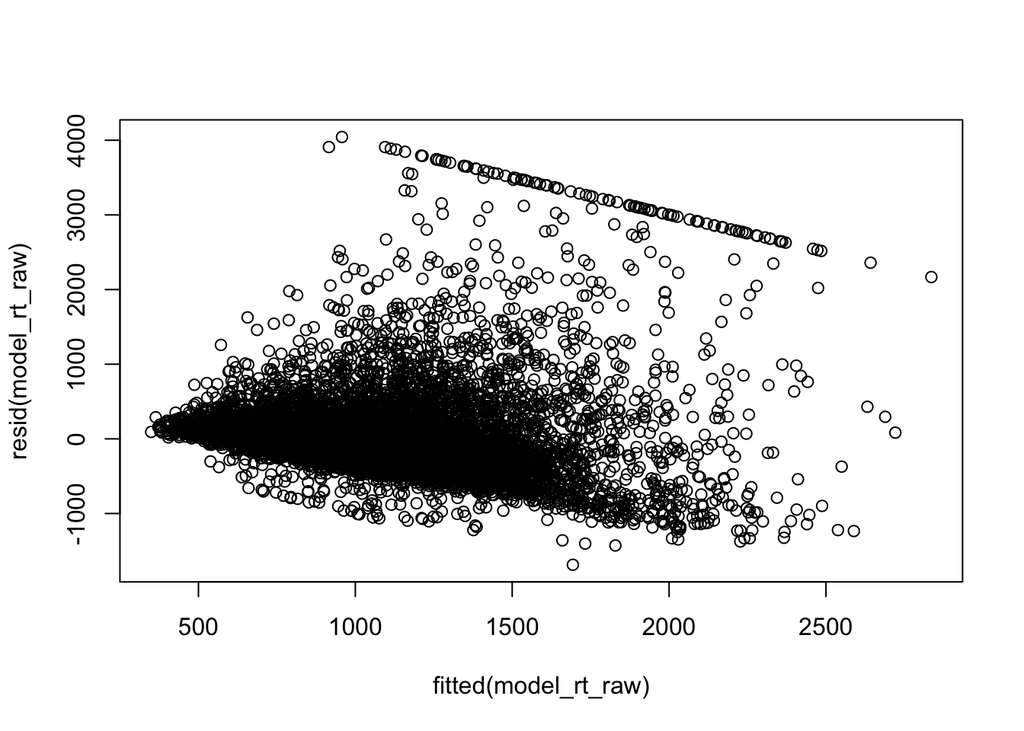

#### Log RT

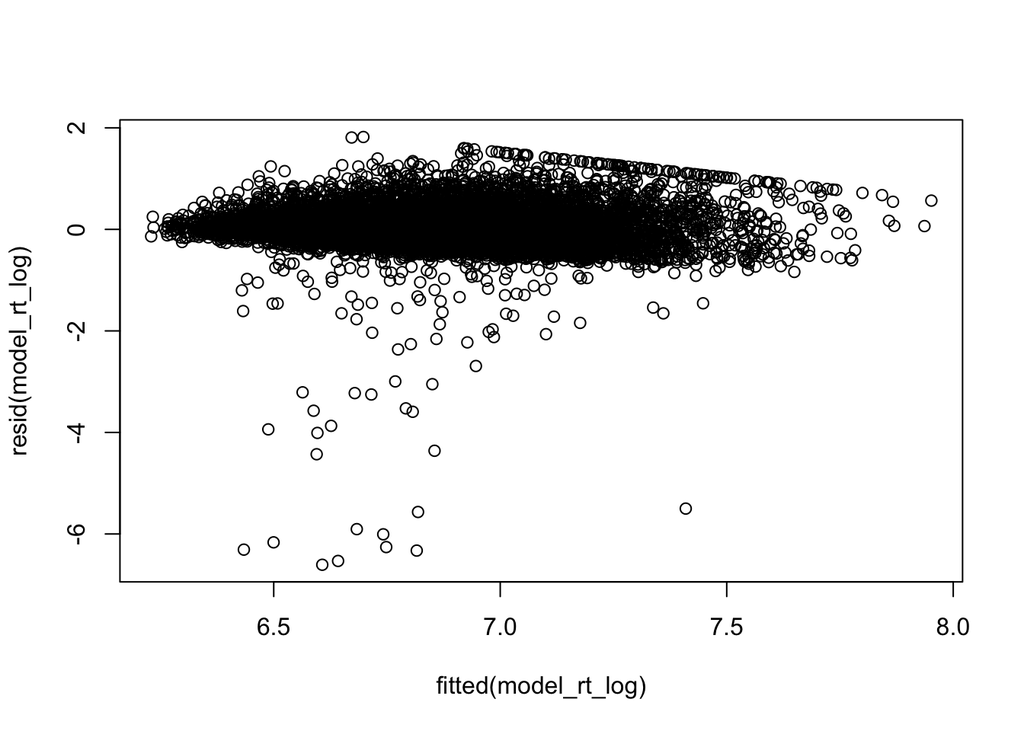

#### GLMM RT - Inverse Gaussian Distribution with Identity Link

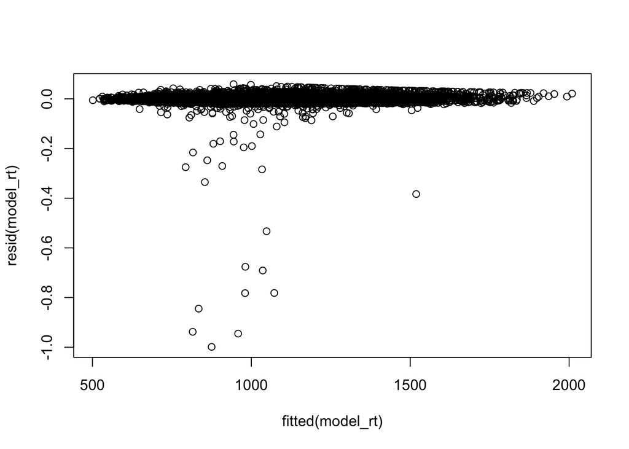

## Technical Notes

1. Model fails to converge when the random effect of Stimulus is allowed to vary across Conditions (1 + Condition | Stimulus) vs (1 | Stimulus). Double-checked with allFit.
2. Model fails to converge with (1 + Condition | SubjectID) compared to (1 | SubjectID). This is likely due to there being little variance in the random slopes for conditions across subjects.
3. The above models can be made to converge. Multiple iterations of the model are run with each starting where the previous model stopped. The model converges around the third iteration.
4. The Inverse Gaussian distribution provides a much better model fit than the Gamma distribution in terms of marginal R^2. I don’t know if the AIC and BIC can be compared between the two models, but I’ve still provided them below.  
   Inverse Gaussian (RT Model): Marginal R^2 = 0.671; AIC = 197799.1; BIC = 197865.8  
   Gamma (RT Model): Marginal R^2 = 0.324; AIC = 179634.0; BIC = 179700.8

## References

### Papers

Lo, S., & Andrews, S. (2015). To transform or not to transform: using generalized linear mixed models to analyse reaction time data. *Frontiers in Psychology, 6*. [doi:10.3389/fpsyg.2015.01171](https://doi.org/10.3389/fpsyg.2015.01171)

### R Packages

Generated using a function from [Stack Overflow](https://stackoverflow.com/questions/15688758/r-stats-citation-for-a-scientific-paper)

RStudio Team (2016). *RStudio: Integrated Development Environment for R*. RStudio, Inc., Boston, MA. <URL: http://www.rstudio.com/>.

R Core Team (2018). *R: A Language and Environment for Statistical Computing*. R Foundation for Statistical Computing, Vienna, Austria. <URL: https://www.R-project.org/>.

Hothorn T, Bretz F, Westfall P (2008). “Simultaneous Inference in General Parametric Models.” *Biometrical Journal*, *50*(3), 346-363.

Hothorn T (2019). *TH.data: TH’s Data Archive*. R package version 1.0-10, <URL: https://CRAN.R-project.org/package=TH.data>.

Venables WN, Ripley BD (2002). *Modern Applied Statistics with S*, Fourth edition. Springer, New York. ISBN 0-387-95457-0, <URL: http://www.stats.ox.ac.uk/pub/MASS4>.

Therneau T (2015). *A Package for Survival Analysis in S*. version 2.38, <URL: https://CRAN.R-project.org/package=survival>.

Terry M. Therneau, Patricia M. Grambsch (2000). *Modeling Survival Data: Extending the Cox Model*. Springer, New York. ISBN 0-387-98784-3.

Genz A, Bretz F, Miwa T, Mi X, Leisch F, Scheipl F, Hothorn T (2018). *mvtnorm: Multivariate Normal and t Distributions*. R package version 1.0-8, <URL: https://CRAN.R-project.org/package=mvtnorm>.

Genz A, Bretz F (2009). *Computation of Multivariate Normal and t Probabilities*, series Lecture Notes in Statistics. Springer-Verlag, Heidelberg. ISBN 978-3-642-01688-2.

Lüdecke D (2019). *sjlabelled: Labelled Data Utility Functions (Version 1.0.16)*. doi: 10.5281/zenodo.1249215 (URL: http://doi.org/10.5281/zenodo.1249215), <URL: https://CRAN.R-project.org/package=sjlabelled>.

Lüdecke D (2018). “sjmisc: Data and Variable Transformation Functions.” *Journal of Open Source Software*, *3*(26), 754. doi: 10.21105/joss.00754 (URL: http://doi.org/10.21105/joss.00754).

Lüdecke D (2018). *sjPlot: Data Visualization for Statistics in Social Science*. doi: 10.5281/zenodo.1308157 (URL: http://doi.org/10.5281/zenodo.1308157), R package version 2.6.2, <URL: https://CRAN.R-project.org/package=sjPlot>.

Bates D, Mächler M, Bolker B, Walker S (2015). “Fitting Linear Mixed-Effects Models Using lme4.” *Journal of Statistical Software*, *67*(1), 1-48. doi: 10.18637/jss.v067.i01 (URL: http://doi.org/10.18637/jss.v067.i01).

Bates D, Maechler M (2018). *Matrix: Sparse and Dense Matrix Classes and Methods*. R package version 1.2-15, <URL: https://CRAN.R-project.org/package=Matrix>.

Wickham H (2019). *forcats: Tools for Working with Categorical Variables (Factors)*. R package version 0.4.0, <URL: https://CRAN.R-project.org/package=forcats>.

Wickham H (2019). *stringr: Simple, Consistent Wrappers for Common String Operations*. R package version 1.4.0, <URL: https://CRAN.R-project.org/package=stringr>.

Wickham H, François R, Henry L, Müller K (2019). *dplyr: A Grammar of Data Manipulation*. R package version 0.8.0.1, <URL: https://CRAN.R-project.org/package=dplyr>.

Henry L, Wickham H (2019). *purrr: Functional Programming Tools*. R package version 0.3.0, <URL: https://CRAN.R-project.org/package=purrr>.

Wickham H, Hester J, Francois R (2018). *readr: Read Rectangular Text Data*. R package version 1.3.1, <URL: https://CRAN.R-project.org/package=readr>.

Wickham H, Henry L (2018). *tidyr: Easily Tidy Data with ‘spread()’ and ‘gather()’ Functions*. R package version 0.8.2, <URL: https://CRAN.R-project.org/package=tidyr>.

Müller K, Wickham H (2019). *tibble: Simple Data Frames*. R package version 2.0.1, <URL: https://CRAN.R-project.org/package=tibble>.

Wickham H (2016). *ggplot2: Elegant Graphics for Data Analysis*. Springer-Verlag New York. ISBN 978-3-319-24277-4, <URL: http://ggplot2.org>.

Wickham H (2017). *tidyverse: Easily Install and Load the ‘Tidyverse’*. R package version 1.2.1, <URL: https://CRAN.R-project.org/package=tidyverse>.